# Practical ML Project

by: Steve Spitz

### Method Summary 1. Load the data 2. Pre-process the data + Remove variables with mostly missing values + Partition data into training and test sets 3. Model the training data + Choose gbm because it is robust to missing values + Examine overall performance, CV performance and variable importance 4. Evaluate model performance on the test set + Confusion matrix  
### 1. Load the data

```r
# pml <- read.csv("https://d396qusza40orc.cloudfront.net/predmachlearn/pml-training.csv", stringsAsFactors=FALSE, na.strings=c("", " ", "NA"))

pml <- read.csv("pml-training.csv", stringsAsFactors=FALSE, na.strings=c("", " ", "NA"))
```

The data are stored in a data frame called ‘pml’.  
### 2. Pre-process the data  
#### Step 1: Break the data by data type

```r
classes <- sapply(pml, class)
table(classes)
```

```
## classes
## character   integer   numeric
##        37        35        88
```

```r
pml.char <- pml[, classes == 'character' & !(names(pml) == 'classe')]
pml.int  <- pml[, classes == 'integer']
pml.num  <- pml[, classes == 'numeric']
pml.dv   <- pml[, names(pml) == 'classe']
```

We see that the data consists of character, integer, and numeric predictors.  
#### Step 2: Investigate missing values (NA’s)

```r
# 33 of 37 character columns are mostly missing values (NAs)
sort(colSums(is.na(pml.char)), decr=T)
charvars.na <- sum(sort(colSums(is.na(pml.char)), decr=T) > 0)

# only 6 of 35 integer columns are mostly missing values (NAs)
sort(colSums(is.na(pml.int)), decr=T)
intvars.na <- sum(sort(colSums(is.na(pml.int)), decr=T) > 0)

# 61 of 88 numeric columns are mostly missing values (NAs)
sort(colSums(is.na(pml.num)), decr=T)
numvars.na <- sum(sort(colSums(is.na(pml.num)), decr=T) > 0)
```

[output not shown]

```r
na.cap <- round(nrow(pml) * 0.5)
pml.char.ok <- subset(pml.char, select = -which(colSums(is.na(pml.char)) > na.cap))
pml.int.ok  <- subset(pml.int, select = -which(colSums(is.na(pml.int)) > na.cap))
pml.num.ok  <- subset(pml.num, select = -which(colSums(is.na(pml.num)) > na.cap))
rm(pml.char, pml.int, pml.num)
```

#### Step 4: Reassemble the predictor data

```r
pml.ok <- cbind.data.frame(pml.char.ok, pml.int.ok, pml.num.ok)
rm(pml.char.ok, pml.int.ok, pml.num.ok)
```

#### Step 5: Remove near zero variance columns

```r
library(caret)
nzv <- nearZeroVar(pml.ok)
pml.ok <- pml.ok[, -(nzv)]
```

#### Step 6: Remove variables that probably aren’t predictive

```r
remove.cols <- names(pml.ok)[grepl("timest", names(pml.ok))]
remove.cols <- c(remove.cols, "X", "user_name")
pml.ok <- pml.ok[, !(names(pml.ok) %in% remove.cols)]
```

Here, we remove the timestamp variables, as well as the observation number variable and the user name variable.  
#### Step 7: Save the names of the remaining predictor columns

```r
pml.predictors <- names(pml.ok)
```

#### Step 8: Append the classe target variable

```r
pml.ok <- cbind.data.frame(pml.ok, classe=pml.dv)
```

#### Step 9: Partition the data into a training set and a test set

```r
set.seed(34595)
trnIdx <- createDataPartition(pml.ok$classe, p=.6, list=FALSE)
pml.train <- pml.ok[trnIdx, ]
pml.test  <- pml.ok[-trnIdx, ]
```

### 3. Model the training data  
#### Step 1: Build a gradient boosting machine model using cross-validation

```r
set.seed(135)
ctrl <- trainControl(method = "cv", number=5, savePred=T, classProbs=T)
pml.gbm <- train(classe~., data=pml.train, method = "gbm", trControl = ctrl)
```

#### Step 2: Look at the model performance and model parameters

```r
pml.gbm
```

```
## Stochastic Gradient Boosting
##
## 11776 samples
##    53 predictor
##     5 classes: 'A', 'B', 'C', 'D', 'E'
##
## No pre-processing
## Resampling: Cross-Validated (5 fold)
##
## Summary of sample sizes: 9422, 9420, 9421, 9420, 9421
##
## Resampling results across tuning parameters:
##
##   interaction.depth  n.trees  Accuracy  Kappa  Accuracy SD  Kappa SD
##   1                   50      0.8       0.7    0.004        0.005
##   1                  100      0.8       0.8    0.005        0.006
##   1                  150      0.9       0.8    0.006        0.008
##   2                   50      0.9       0.9    0.004        0.005
##   2                  100      0.9       0.9    0.005        0.006
##   2                  150      1.0       1.0    0.004        0.005
##   3                   50      0.9       0.9    0.005        0.006
##   3                  100      1.0       1.0    0.004        0.005
##   3                  150      1.0       1.0    0.004        0.005
##
## Tuning parameter 'shrinkage' was held constant at a value of 0.1
## Accuracy was used to select the optimal model using  the largest value.
## The final values used for the model were n.trees = 150,
##  interaction.depth = 3 and shrinkage = 0.1.
```

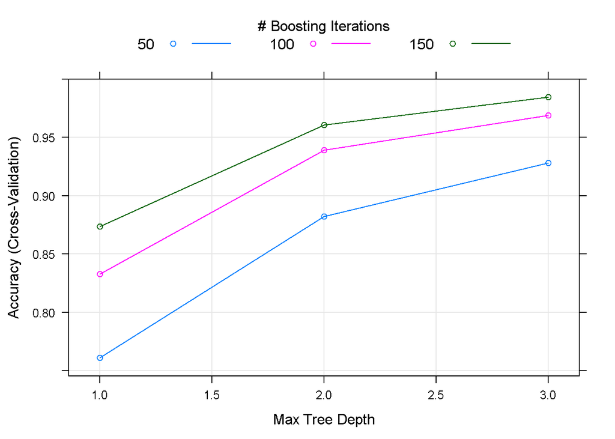

```r
plot(pml.gbm)
```

The graph shows that the highest accuracy is achieved with 150 iterations and a maximum tree depth of 3. A tree depth greater than two enables variable interactions.  
#### Step 3: Examine the model’s performance on the cross-validation folds

```r
pml.gbm$resample
```

```
##   Accuracy  Kappa Resample
## 1   0.9834 0.9791    Fold4
## 2   0.9873 0.9839    Fold3
## 3   0.9779 0.9721    Fold2
## 4   0.9873 0.9839    Fold5
## 5   0.9868 0.9833    Fold1
```

We see that accuracy across all CV folds is consistent.  
#### Step 4: Which variables are most important?

```r
gbmImp <- varImp(pml.gbm, scale = FALSE)
gbmImp
```

```
## gbm variable importance
##
##   only 20 most important variables shown (out of 53)
##
##                   Overall
## roll_belt            2275
## num_window           2117
## pitch_forearm        1196
## magnet_dumbbell_z     764
## yaw_belt              707
## magnet_dumbbell_y     620
## roll_forearm          490
## magnet_belt_z         380
## accel_forearm_x       278
## gyros_dumbbell_y      265
## gyros_belt_z          263
## pitch_belt            253
## roll_dumbbell         247
## accel_dumbbell_z      241
## accel_dumbbell_y      208
## accel_dumbbell_x      159
## accel_forearm_z       130
## magnet_forearm_z      125
## magnet_belt_y         112
## magnet_arm_x          108
```

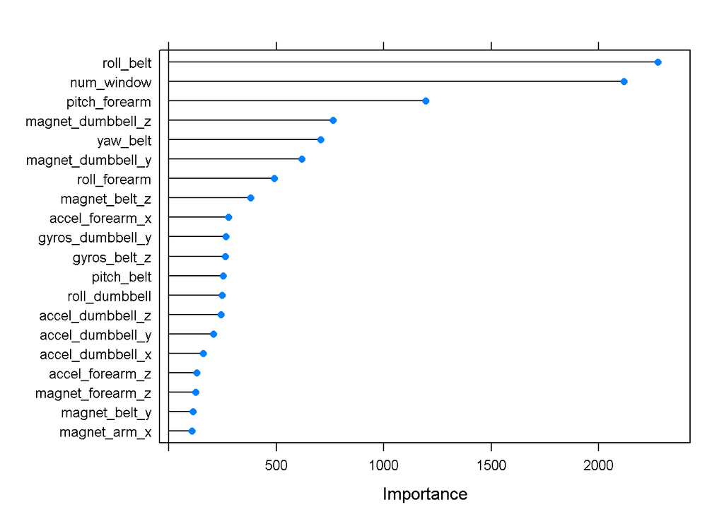

```r
plot(gbmImp, top=20)
```

### 3. Evaluate model performance on the test set

```r
pml.gbm.perf <- predict(pml.gbm, newdata=pml.test)
# head(pml.gbm.perf)
confusionMatrix(data=pml.gbm.perf, reference=pml.test$classe)
```

```
## Confusion Matrix and Statistics
##
##           Reference
## Prediction    A    B    C    D    E
##          A 2227    8    0    2    3
##          B    5 1496   21    2   12
##          C    0   14 1344   14    1
##          D    0    0    3 1267   16
##          E    0    0    0    1 1410
##
## Overall Statistics
##
##                Accuracy : 0.987
##                  95% CI : (0.984, 0.989)
##     No Information Rate : 0.284
##     P-Value [Acc > NIR] : <2e-16
##
##                   Kappa : 0.984
##  Mcnemar's Test P-Value : NA
##
## Statistics by Class:
##
##                      Class: A Class: B Class: C Class: D Class: E
## Sensitivity             0.998    0.986    0.982    0.985    0.978
## Specificity             0.998    0.994    0.996    0.997    1.000
## Pos Pred Value          0.994    0.974    0.979    0.985    0.999
## Neg Pred Value          0.999    0.997    0.996    0.997    0.995
## Prevalence              0.284    0.193    0.174    0.164    0.184
## Detection Rate          0.284    0.191    0.171    0.161    0.180
## Detection Prevalence    0.285    0.196    0.175    0.164    0.180
## Balanced Accuracy       0.998    0.990    0.989    0.991    0.989
```

```r
# this is good performance
```

The model’s performance on holdout data is excellent. The confusion matrix shows that class predictions generally agree with the observed class values.